# Estudio de la expresión génica vinculada al grado histológico en tumores de mama

Javier Arenas Villanueva

# Introducción

El objetivo de este Trabajo de Fin de Máster es obtener un método que permita realizar la clasificación del grado histológico de muestras tumorales de mama a partir de datos de expresión génica obtenidos de la base de datos GEO. Para ello, se emplea un conjunto de datos principal (GSE4922), utilizado para el desarrollo y entrenamiento de los modelos, y un segundo conjunto independiente (GSE2990), reservado para realizar una validación externa del sistema.

Antes de construir los modelos de clasificación, ambos conjuntos de datos se procesan de forma conjunta con el fin de garantizar que las muestras sean comparables entre sí, evitando el *batch effect*. En primer lugar, se selecciona la misma plataforma de microarrays en ambos estudios (GPL96 - Affymetrix Human Genome U133A Array) y se conservan únicamente los probesets comunes. Posteriormente, se aplica el método ComBat.

Una vez corregidos los datos, el conjunto original se utiliza para llevar a cabo el entrenamiento, selección de características y comparación de distintos modelos de clasificación. Finalmente, el conjunto externo se reserva para evaluar la capacidad de generalización del modelo seleccionado sobre los datos externos.

# Preparación del entorno de trabajo

Antes de comenzar el análisis de los datos, se configura el entorno de trabajo para llevar a cabo el análisis. Por un lado, se importan las librerías esenciales para realizarlo. Por otro lado, se establecen los parámetros generales que se aplicarán en el proceso, como los identificadores de los conjuntos de datos utilizados, la plataforma común elegida para trabajar de los estudios y la semilla empleada para garantizar la reproducibilidad de los resultados.

```r
library(GEOquery)
library(Biobase)
library(sva)
library(ggplot2)
library(caret)
library(pheatmap)
library(mRMRe)
library(glmnet)
library(kernlab)
library(randomForest)
library(MASS)
```

```r
seed <- 123

# Identificadores de los conjuntos de datos
gse_original_id <- "GSE4922"
gse_externo_id  <- "GSE2990"

# Plataforma común utilizada en ambos estudios
plataforma_usada <- "GPL96"

set.seed(seed)
```

# Descarga y selección de los conjuntos de datos

Una vez definido el entorno de trabajo, se procede a la descarga de los conjuntos de datos que se utilizan en el análisis. En este caso, se emplea el conjunto **GSE4922** como base para el desarrollo de los modelos y el conjunto **GSE2990** como conjunto externo para la posterior validación externa.

Los estudios pueden tener información procedente de distintas plataformas de microarrays. Por este motivo, este aspecto se tiene en cuenta durante la selección de los datos, escogiendo únicamente la plataforma **GPL96**, correspondiente a Affymetrix Human Genome U133A Array.

En este caso, los datos se descargan desde GEO a partir del archivo **Series Matrix**, que contiene la matriz de expresión procesada junto con los metadatos asociados a las muestras.

## GSE4922

```r
# Descargamos el conjunto de datos GSE4922
gse_GSE4922 <- getGEO(gse_original_id, GSEMatrix = TRUE)
```

```
## Found 2 file(s)
```

```
## GSE4922-GPL96_series_matrix.txt.gz
```

```
## GSE4922-GPL97_series_matrix.txt.gz
```

```r
# Seleccionamos la plataforma GPL96 en GSE4922
idx_gpl96_GSE4922 <- which(sapply(gse_GSE4922, annotation) == plataforma_usada)
gpl96_GSE4922 <- gse_GSE4922[[idx_gpl96_GSE4922[1]]]
```

```r
# Obtenemos la matriz de expresión de GSE4922
expr_raw_GSE4922 <- exprs(gpl96_GSE4922)
```

```r
# Obtenemos la información de la variable objetivo (grado histológico)
grade_raw_GSE4922 <- as.character(pData(gpl96_GSE4922)$characteristics_ch1.1)
grade_num_GSE4922 <- as.numeric(gsub("[^0-9]", "", grade_raw_GSE4922))

# Convertimos el grado histológico en una variable categórica
grade_GSE4922 <- factor(
  grade_num_GSE4922,
  levels = c(1, 2, 3),
  labels = c("G1", "G2", "G3")
)
```

## GSE2990

```r
# Descargamos el conjunto de datos GSE2990
gse_GSE2990 <- getGEO(gse_externo_id, GSEMatrix = TRUE)
```

```
## Found 1 file(s)
```

```
## GSE2990_series_matrix.txt.gz
```

```
## Using locally cached version of GPL96 found here:
## /var/folders/d4/sng196bj3pqcd58xzgtx70ph0000gn/T//RtmpKTMbqY/GPL96.soft.gz
```

```r
# Seleccionamos la plataforma GPL96 en GSE2990
idx_gpl96_GSE2990 <- which(sapply(gse_GSE2990, annotation) == plataforma_usada)
gpl96_GSE2990 <- gse_GSE2990[[idx_gpl96_GSE2990[1]]]
```

```r
# Obtenemos la matriz de expresión de GSE2990
expr_raw_GSE2990 <- exprs(gpl96_GSE2990)
```

```r
# Obtenemos la información de la variable objetivo (grado histológico)
grade_raw_GSE2990 <- as.character(pData(gpl96_GSE2990)[["grade:ch1"]])
grade_num_GSE2990 <- as.numeric(gsub("[^0-9]", "", grade_raw_GSE2990))

# Convertimos el grado histológico en una variable categórica
grade_GSE2990 <- factor(
  grade_num_GSE2990,
  levels = c(1, 2, 3),
  labels = c("G1", "G2", "G3")
)
```

Una vez tenemos los datos de ambos estudios, preparamos las matrices y comprobamos tanto la dimensión como la distribución de los grados en ambos estudios.

```r
# Transponemos la matriz de GSE4922 para tener muestras en filas y probesets en columnas
expr_GSE4922 <- as.data.frame(
  t(expr_raw_GSE4922),
  check.names = FALSE
)

# Transponemos la matriz de GSE2990 para tener muestras en filas y probesets en columnas
expr_GSE2990 <- as.data.frame(
  t(expr_raw_GSE2990),
  check.names = FALSE
)

# Identificamos las muestras con grado histológico válido en GSE4922
keep_GSE4922 <- !is.na(grade_GSE4922)

# Filtramos las muestras válidas de GSE4922
expr_GSE4922 <- expr_GSE4922[keep_GSE4922, , drop = FALSE]
grade_GSE4922 <- droplevels(grade_GSE4922[keep_GSE4922])

# Identificamos las muestras con grado histológico válido en GSE2990
keep_GSE2990 <- !is.na(grade_GSE2990)

# Filtramos las muestras válidas de GSE2990
expr_GSE2990 <- expr_GSE2990[keep_GSE2990, , drop = FALSE]
grade_GSE2990 <- droplevels(grade_GSE2990[keep_GSE2990])

# Comprobamos las dimensiones finales de GSE4922
dim(expr_GSE4922)
```

```
## [1]   289 22283
```

```r
# Comprobamos la distribución del grado histológico en GSE4922
table(grade_GSE4922)
```

```
## grade_GSE4922
##  G1  G2  G3
##  68 166  55
```

```r
# Comprobamos las dimensiones finales de GSE2990
dim(expr_GSE2990)
```

```
## [1]   172 22283
```

```r
# Comprobamos la distribución del grado histológico en GSE2990
table(grade_GSE2990)
```

```
## grade_GSE2990
## G1 G2 G3
## 67 46 59
```

Tras la preparación inicial de los datos, se puede observar que el estudio GSE4922 está formado por 289 muestras y 22.283 probesets. La distribución del grado histológico muestra un mayor número de muestras de grado G2, con 166 casos, seguido de G1 con 68 muestras y G3 con 55 muestras. Por otro lado, el conjunto externo GSE2990 está formado por 172 muestras y el mismo número de probesets, 22.283, al estar basado en la misma plataforma. En este caso, la distribución de clases es más equilibrada, con 67 muestras de G1, 46 de G2 y 59 de G3.

# Selección de probesets comunes

El análisis se realiza a nivel de *probeset*, ya que un mismo probeset no siempre tiene relación uno a uno con un gen. Por ejemplo, el probeset `1007_s_at` está asociado a más de un símbolo génico. En la siguiente salida se observa que tiene asociados `DDR1` y `MIR4640`.

```r
# Obtenemos la anotación de la plataforma GPL96
feature_gpl96_GSE4922 <- fData(gpl96_GSE4922)

# Consultamos la anotación del probeset 1007_s_at
feature_gpl96_GSE4922["1007_s_at", c("ID", "Gene Symbol", "Gene Title")]
```

```
##                  ID      Gene Symbol
## 1007_s_at 1007_s_at DDR1 /// MIR4640
##                                                              Gene Title
## 1007_s_at discoidin domain receptor tyrosine kinase 1 /// microRNA 4640
```

Una vez preparadas las matrices de expresión de ambos estudios, se identifican los probesets comunes entre GSE4922 y GSE2990. Aunque ambos conjuntos proceden de la misma plataforma y presentan el mismo número de probesets, este paso permite asegurar que las variables sean exactamente las mismas y que se encuentren en el mismo orden antes de combinar los datos. De esta forma, se evita introducir errores al unir las matrices y se garantiza que cada columna represente el mismo probeset en ambos estudios.

```r
# Identificamos los probesets comunes entre GSE4922 y GSE2990
probesets_comunes <- intersect(
  colnames(expr_GSE4922),
  colnames(expr_GSE2990)
)

# Comprobamos el número de probesets comunes
length(probesets_comunes)
```

```
## [1] 22283
```

```r
# Conservamos únicamente los probesets comunes en GSE4922
expr_GSE4922_common <- expr_GSE4922[, probesets_comunes, drop = FALSE]

# Conservamos únicamente los probesets comunes en GSE2990
expr_GSE2990_common <- expr_GSE2990[, probesets_comunes, drop = FALSE]

# Comprobamos las dimensiones de las matrices filtradas
dim(expr_GSE4922_common)
```

```
## [1]   289 22283
```

```r
dim(expr_GSE2990_common)
```

```
## [1]   172 22283
```

```r
# Comprobamos que los probesets están en el mismo orden en ambos estudios
identical(
  colnames(expr_GSE4922_common),
  colnames(expr_GSE2990_common)
)
```

```
## [1] TRUE
```

La comprobación confirma que ambos estudios comparten **22.283 probesets**. Al no haber ningún probeset diferente, el conjunto **GSE4922** mantiene **289 muestras** y **22.283 variables**, mientras que el conjunto **GSE2990** conserva **172 muestras** y el mismo número de variables. Además, el resultado `TRUE` indica que los probesets se encuentran en el mismo orden en ambos conjuntos, por lo que las matrices pueden combinarse de forma segura en los pasos posteriores.

# *batch effect*

## Comprobación del *batch effect*

Antes de aplicar la corrección mediante ComBat, se realiza un análisis de componentes principales (PCA) con el objetivo de visualizar si las muestras tienden a agruparse en función del estudio de origen. Este paso permite comprobar de forma exploratoria la presencia de diferencias asociadas al lote (*batch*), en este caso representado por el conjunto de datos al que pertenece cada muestra.

Para ello, se combinan las matrices de expresión de GSE4922 y GSE2990, y se crea una variable que identifica el origen de cada muestra.

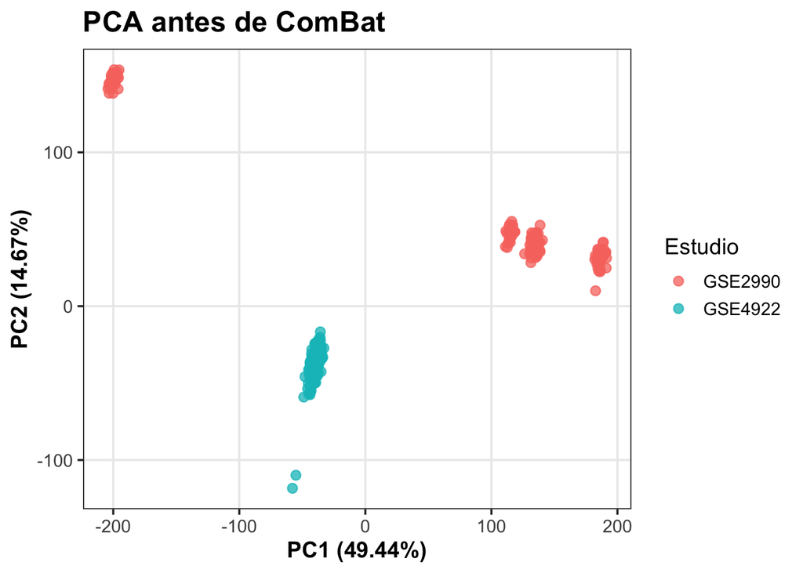

```r
# Unimos las matrices de expresión de ambos estudios
expr_total_antes <- rbind(
  expr_GSE4922_common,
  expr_GSE2990_common
)

# Creamos la variable que indica el estudio de origen de cada muestra
batch <- factor(c(
  rep("GSE4922", nrow(expr_GSE4922_common)),
  rep("GSE2990", nrow(expr_GSE2990_common))
))

# Creamos la variable biológica correspondiente al grado histológico
grade_total <- factor(
  c(as.character(grade_GSE4922), as.character(grade_GSE2990)),
  levels = c("G1", "G2", "G3")
)

# Calculamos el PCA antes de aplicar ComBat
pca_antes <- prcomp(
  expr_total_antes,
  center = TRUE,
  scale. = TRUE
)

# Calculamos el porcentaje de varianza explicada por cada componente
var_exp_antes <- round(
  100 * pca_antes$sdev^2 / sum(pca_antes$sdev^2),
  2
)

# Creamos el data frame con los resultados del PCA
pca_antes_df <- data.frame(
  PC1 = pca_antes$x[, 1],
  PC2 = pca_antes$x[, 2],
  batch = batch,
  grade = grade_total
)

# Representamos el PCA antes de aplicar ComBat
ggplot(pca_antes_df, aes(x = PC1, y = PC2, color = batch)) +
  geom_point(size = 2.4, alpha = 0.75) +
  theme_bw(base_size = 14) +
  labs(
    title = "PCA antes de ComBat",
    x = paste0("PC1 (", var_exp_antes[1], "%)"),
    y = paste0("PC2 (", var_exp_antes[2], "%)"),
    color = "Estudio"
  ) +
  theme(
    plot.title = element_text(face = "bold", size = 18),
    axis.title = element_text(face = "bold"),
    legend.position = "right",
    panel.grid.minor = element_blank()
  )
```

En la representación PCA antes de aplicar ComBat se observa una separación clara entre las muestras en función del estudio de origen. Las muestras de GSE4922 aparecen agrupadas en una región diferente a las de GSE2990, especialmente a lo largo del primer componente principal, que explica el 49,44 % de la variabilidad total. Esta separación indica la presencia de un efecto de lote asociado al conjunto de datos, por lo que resulta necesario aplicar una corrección antes de utilizar ambos estudios de forma conjunta.

## Corrección del *batch effect* mediante ComBat

Una vez identificada la separación entre estudios, se aplica el método ComBat para corregir el efecto de lote asociado al origen de las muestras.

```r
# Creamos el modelo biológico que queremos conservar durante la corrección
mod_combat <- model.matrix(~ grade_total)

# Aplicamos ComBat para corregir el efecto de lote
expr_combat_matrix <- ComBat(
  dat = t(as.matrix(expr_total_antes)),
  batch = batch,
  mod = mod_combat
)
```

```
## Found2batches
```

```
## Adjusting for2covariate(s) or covariate level(s)
```

```
## Standardizing Data across genes
```

```
## Fitting L/S model and finding priors
```

```
## Finding parametric adjustments
```

```
## Adjusting the Data
```

```r
# Volvemos la matriz corregida al formato muestras por probesets
expr_combat <- as.data.frame(
  t(expr_combat_matrix),
  check.names = FALSE
)

# Comprobamos las dimensiones de la matriz corregida
dim(expr_combat)
```

```
## [1]   461 22283
```

Tras aplicar ComBat, se repite el análisis de componentes principales con la matriz corregida. El objetivo de este paso es comprobar visualmente si la corrección ha reducido la separación entre los estudios observada antes de aplicar el método.

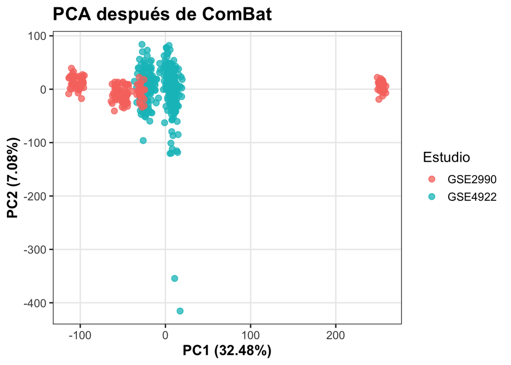

```r
# Calculamos el PCA después de aplicar ComBat
pca_despues <- prcomp(
  expr_combat,
  center = TRUE,
  scale. = TRUE
)

# Calculamos el porcentaje de varianza explicada por cada componente
var_exp_despues <- round(
  100 * pca_despues$sdev^2 / sum(pca_despues$sdev^2),
  2
)

# Creamos el data frame con los resultados del PCA corregido
pca_despues_df <- data.frame(
  PC1 = pca_despues$x[, 1],
  PC2 = pca_despues$x[, 2],
  batch = batch,
  grade = grade_total
)

# Representamos el PCA después de aplicar ComBat
ggplot(pca_despues_df, aes(x = PC1, y = PC2, color = batch)) +
  geom_point(size = 2.4, alpha = 0.75) +
  theme_bw(base_size = 14) +
  labs(
    title = "PCA después de ComBat",
    x = paste0("PC1 (", var_exp_despues[1], "%)"),
    y = paste0("PC2 (", var_exp_despues[2], "%)"),
    color = "Estudio"
  ) +
  theme(
    plot.title = element_text(face = "bold", size = 18),
    axis.title = element_text(face = "bold"),
    legend.position = "right",
    panel.grid.minor = element_blank()
  )
```

Después de aplicar ComBat, la representación PCA muestra una reducción clara de la separación entre ambos estudios. A diferencia del PCA inicial, donde las muestras aparecían agrupadas principalmente según su conjunto de origen, tras la corrección se observa una mayor proximidad entre GSE4922 y GSE2990. Además, el porcentaje de varianza explicado por el primer componente principal disminuye del 49,44 % al 32,48 %, lo que indica que parte de la variabilidad asociada al lote ha sido reducida.

Aun así, se mantienen algunos grupos diferenciados y muestras alejadas, especialmente dentro del conjunto externo. Esto indica que ComBat reduce el efecto de lote, pero no elimina completamente toda la variabilidad existente entre los estudios.

### Separación de los conjuntos tras la corrección

Una vez corregido el efecto de lote, la matriz combinada se separa de nuevo en los dos conjuntos originales. De esta forma, el conjunto GSE4922 se mantiene como base para el entrenamiento, selección de características y comparación de modelos, mientras que GSE2990 se reserva como conjunto externo para evaluar la capacidad de generalización del modelo final.

```r
# Recuperamos la matriz corregida correspondiente a GSE4922
expr <- expr_combat[rownames(expr_GSE4922_common), , drop = FALSE]

# Recuperamos la variable objetivo correspondiente a GSE4922
grade <- factor(
  grade_GSE4922,
  levels = c("G1", "G2", "G3")
)

# Recuperamos la matriz corregida correspondiente a GSE2990
expr_validacion_externa <- expr_combat[rownames(expr_GSE2990_common), , drop = FALSE]

# Recuperamos la variable objetivo correspondiente a GSE2990
grade_validacion_externa <- factor(
  grade_GSE2990,
  levels = c("G1", "G2", "G3")
)

# Comprobamos las dimensiones del conjunto principal corregido
dim(expr)
```

```
## [1]   289 22283
```

```r
# Comprobamos la distribución del grado histológico en el conjunto principal
table(grade)
```

```
## grade
##  G1  G2  G3
##  68 166  55
```

```r
# Comprobamos las dimensiones del conjunto externo corregido
dim(expr_validacion_externa)
```

```
## [1]   172 22283
```

```r
# Comprobamos la distribución del grado histológico en el conjunto externo
table(grade_validacion_externa)
```

```
## grade_validacion_externa
## G1 G2 G3
## 67 46 59
```

La separación final mantiene correctamente las dimensiones esperadas. El conjunto principal **GSE4922** queda formado por **289 muestras** y **22.283 probesets**, con una distribución de **68 muestras G1**, **166 muestras G2** y **55 muestras G3**. Por otro lado, el conjunto externo **GSE2990** queda formado por **172 muestras** y **22.283 probesets**, con **67 muestras G1**, **46 muestras G2** y **59 muestras G3**.

# División del conjunto principal

Una vez obtenida la matriz corregida del conjunto principal, se divide GSE4922 en un subconjunto de entrenamiento y un subconjunto de prueba interna. El conjunto de entrenamiento se utilizará para realizar la selección de características y ajustar los modelos, mientras que el conjunto de prueba interna permitirá evaluar su rendimiento antes de aplicarlos sobre la cohorte externa GSE2990.

La partición se realiza de forma estratificada, manteniendo la proporción de muestras de cada grado histológico en ambos subconjuntos.

```r
train_prop <- 0.70
```

```r
# Creamos una partición del conjunto principal
idx_train <- createDataPartition(
  grade,
  p = train_prop,
  list = FALSE
)

# Obtenemos la matriz de entrenamiento
expr_train <- expr[idx_train, , drop = FALSE]

# Obtenemos la matriz de prueba interna
expr_test <- expr[-idx_train, , drop = FALSE]

# Obtenemos la variable objetivo del conjunto de entrenamiento
grade_train <- droplevels(grade[idx_train])

# Obtenemos la variable objetivo de prueba interna
grade_test <- droplevels(grade[-idx_train])

# Comprobamos las dimensiones de entrenamiento
dim(expr_train)
```

```
## [1]   204 22283
```

```r
# Comprobamos la distribución del grado histológico en entrenamiento
table(grade_train)
```

```
## grade_train
##  G1  G2  G3
##  48 117  39
```

```r
# Comprobamos las dimensiones de prueba interna
dim(expr_test)
```

```
## [1]    85 22283
```

```r
# Comprobamos la distribución del grado histológico en prueba interna
table(grade_test)
```

```
## grade_test
## G1 G2 G3
## 20 49 16
```

La partición estratificada genera un conjunto de train formado por **204 muestras** y **22.283 probesets**, mientras que el conjunto de test queda formado por **85 muestras** y el mismo número de variables. La distribución de clases se mantiene proporcional en ambos subconjuntos, el train contiene **48 muestras G1**, **117 muestras G2** y **39 muestras G3**, mientras que la test conserva **20 muestras G1**, **49 muestras G2** y **16 muestras G3**. No obstante, en ambos subconjuntos se mantiene el predominio de la clase **G2**, por lo que el desbalance de clases sigue presente tras la partición. Por este motivo, en la fase de entrenamiento de los modelos se incorporará **SMOTE** dentro de la validación cruzada.

# Almacenamiento y carga de los datos

Con el objetivo de evitar repetir todo el proceso de descarga, preparación, corrección por ComBat y partición de los datos en cada ejecución, se almacenan los conjuntos ya procesados en archivos CSV. De esta forma, se guardan por separado las matrices de expresión y las variables objetivo correspondientes al conjunto de entrenamiento, al conjunto de prueba interna y al conjunto de validación externa. Este paso permite ahorrar tiempo en ejecuciones posteriores y continuar el análisis directamente desde los datos ya corregidos y divididos. Además, al conservar los archivos generados, se facilita la reproducibilidad del flujo de trabajo y se evita depender de nuevas descargas desde GEO cada vez que se ejecute el documento.

```r
# Creamos una carpeta para guardar los archivos procesados
dir.create("datos_procesados", showWarnings = FALSE)

# Guardamos la matriz de entrenamiento
write.csv(
  expr_train,
  "datos_procesados/expr_train.csv",
  row.names = TRUE
)

# Guardamos la variable objetivo del conjunto de entrenamiento
write.csv(
  data.frame(grade_train = grade_train),
  "datos_procesados/grade_train.csv",
  row.names = TRUE
)

# Guardamos la matriz de prueba interna
write.csv(
  expr_test,
  "datos_procesados/expr_test.csv",
  row.names = TRUE
)

# Guardamos la variable objetivo del conjunto de prueba interna
write.csv(
  data.frame(grade_test = grade_test),
  "datos_procesados/grade_test.csv",
  row.names = TRUE
)

# Guardamos la matriz de validación externa
write.csv(
  expr_validacion_externa,
  "datos_procesados/expr_validacion_externa.csv",
  row.names = TRUE
)

# Guardamos la variable objetivo del conjunto de validación externa
write.csv(
  data.frame(grade_validacion_externa = grade_validacion_externa),
  "datos_procesados/grade_validacion_externa.csv",
  row.names = TRUE
)
```

Posteriormente, estos archivos pueden cargarse de nuevo en el entorno de trabajo. Al hacerlo, se recuperan los nombres de las muestras como identificadores de fila y se mantienen los nombres originales de los probesets. Además, las variables objetivo se convierten de nuevo en factores con los niveles G1, G2 y G3.

```r
# Cargamos la matriz de entrenamiento
expr_train <- read.csv(
  "datos_procesados/expr_train.csv",
  row.names = 1,
  check.names = FALSE
)

# Cargamos la variable objetivo del conjunto de entrenamiento
grade_train <- read.csv(
  "datos_procesados/grade_train.csv",
  row.names = 1
)$grade_train

grade_train <- factor(
  grade_train,
  levels = c("G1", "G2", "G3")
)

# Cargamos la matriz de prueba interna
expr_test <- read.csv(
  "datos_procesados/expr_test.csv",
  row.names = 1,
  check.names = FALSE
)

# Cargamos la variable objetivo del conjunto de prueba interna
grade_test <- read.csv(
  "datos_procesados/grade_test.csv",
  row.names = 1
)$grade_test

grade_test <- factor(
  grade_test,
  levels = c("G1", "G2", "G3")
)

# Cargamos la matriz de validación externa
expr_validacion_externa <- read.csv(
  "datos_procesados/expr_validacion_externa.csv",
  row.names = 1,
  check.names = FALSE
)

# Cargamos la variable objetivo del conjunto de validación externa
grade_validacion_externa <- read.csv(
  "datos_procesados/grade_validacion_externa.csv",
  row.names = 1
)$grade_validacion_externa

grade_validacion_externa <- factor(
  grade_validacion_externa,
  levels = c("G1", "G2", "G3")
)
```

# Comprobaciones de calidad

Una vez cargados los conjuntos de entrenamiento, prueba interna y validación externa, se realizan una serie de comprobaciones básicas para verificar que los datos conservan una estructura adecuada para el modelado. En concreto, se evalúa la presencia de valores ausentes, variables no numéricas, muestras duplicadas y probesets duplicados. Además, se comprueba que los tres conjuntos mantienen los mismos probesets y en el mismo orden.

```r
# Comprobamos valores ausentes en el conjunto de entrenamiento
sum(is.na(expr_train))
```

```
## [1] 0
```

```r
# Comprobamos valores ausentes en el conjunto de prueba interna
sum(is.na(expr_test))
```

```
## [1] 0
```

```r
# Comprobamos valores ausentes en el conjunto de validación externa
sum(is.na(expr_validacion_externa))
```

```
## [1] 0
```

```r
# Comprobamos variables no numéricas en el conjunto de entrenamiento
sum(!sapply(expr_train, is.numeric))
```

```
## [1] 0
```

```r
# Comprobamos variables no numéricas en el conjunto de prueba interna
sum(!sapply(expr_test, is.numeric))
```

```
## [1] 0
```

```r
# Comprobamos variables no numéricas en el conjunto de validación externa
sum(!sapply(expr_validacion_externa, is.numeric))
```

```
## [1] 0
```

```r
# Comprobamos muestras duplicadas en cada conjunto
sum(duplicated(rownames(expr_train)))
```

```
## [1] 0
```

```r
sum(duplicated(rownames(expr_test)))
```

```
## [1] 0
```

```r
sum(duplicated(rownames(expr_validacion_externa)))
```

```
## [1] 0
```

```r
# Comprobamos probesets duplicados en cada conjunto
sum(duplicated(colnames(expr_train)))
```

```
## [1] 0
```

```r
sum(duplicated(colnames(expr_test)))
```

```
## [1] 0
```

```r
sum(duplicated(colnames(expr_validacion_externa)))
```

```
## [1] 0
```

```r
# Comprobamos que los probesets coinciden entre entrenamiento y prueba interna
identical(colnames(expr_train), colnames(expr_test))
```

```
## [1] TRUE
```

```r
# Comprobamos que los probesets coinciden entre entrenamiento y validación externa
identical(colnames(expr_train), colnames(expr_validacion_externa))
```

```
## [1] TRUE
```

Las comprobaciones confirman que los conjuntos cargados presentan una estructura adecuada para continuar el análisis. No se detectan valores ausentes, variables no numéricas, muestras duplicadas ni probesets duplicados en ninguno de los tres conjuntos. Además, los resultados `TRUE` indican que los probesets coinciden y se encuentran en el mismo orden entre el conjunto de entrenamiento, el conjunto de prueba interna y el conjunto de validación externa.

# **Distribución de las expresiones**

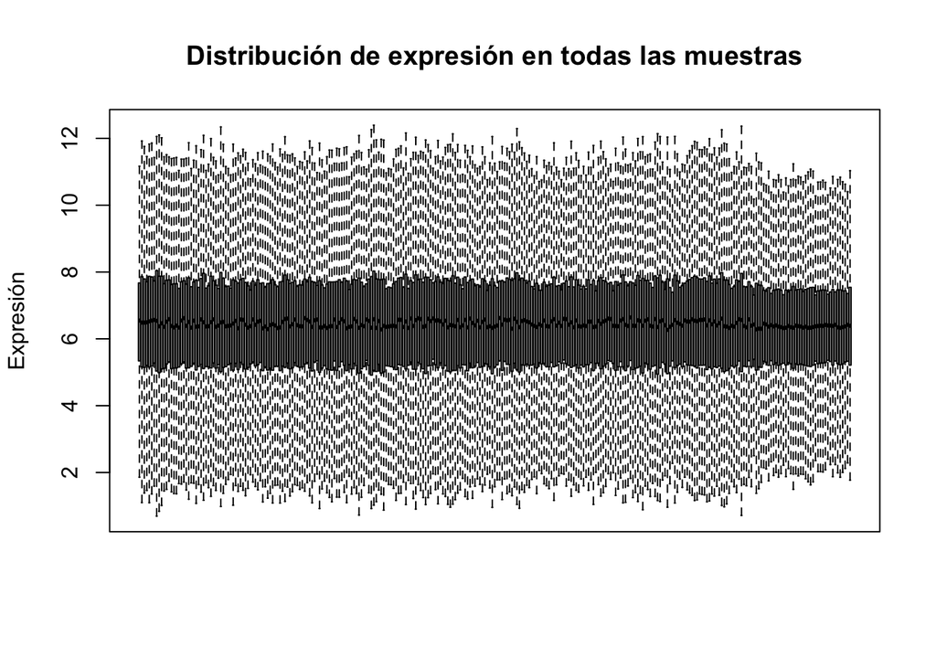

```r
# Convertimos la expresión del conjunto principal a matriz numérica
expr_mat <- as.matrix(expr)

# Representamos la distribución de expresión en todas las muestras
boxplot(
  t(expr_mat),
  xaxt = "n",
  main = "Distribución de expresión en todas las muestras",
  ylab = "Expresión",
  outline = FALSE
)
```

Las distribuciones de expresión son comparables entre muestras, sin observarse muestras claramente desplazadas respecto al conjunto general. Esto sugiere que los datos presentan una estructura adecuada para continuar con el análisis exploratorio y el posterior modelado supervisado.

## Análisis exploratorio mediante PCA

A continuación, se realiza un análisis de componentes principales sobre el conjunto principal con el objetivo de observar la distribución global de las muestras en función del grado histológico. Esta representación permite explorar si existen patrones generales en los perfiles de expresión génica que separen, al menos parcialmente, las muestras de grado G1, G2 y G3.

```r
# Obtenemos la varianza de cada probeset
var_probesets <- apply(expr_mat, 2, var)

# Seleccionamos los 1000 probesets más variables
top_var <- names(sort(var_probesets, decreasing = TRUE))[1:1000]
expr_pca <- expr_mat[, top_var, drop = FALSE]

# Calculamos el PCA centrado y escalado
pca <- prcomp(expr_pca, center = TRUE, scale. = TRUE)

# Obtenemos el porcentaje de varianza explicada
var_exp <- round((pca$sdev^2 / sum(pca$sdev^2)) * 100, 2)
```

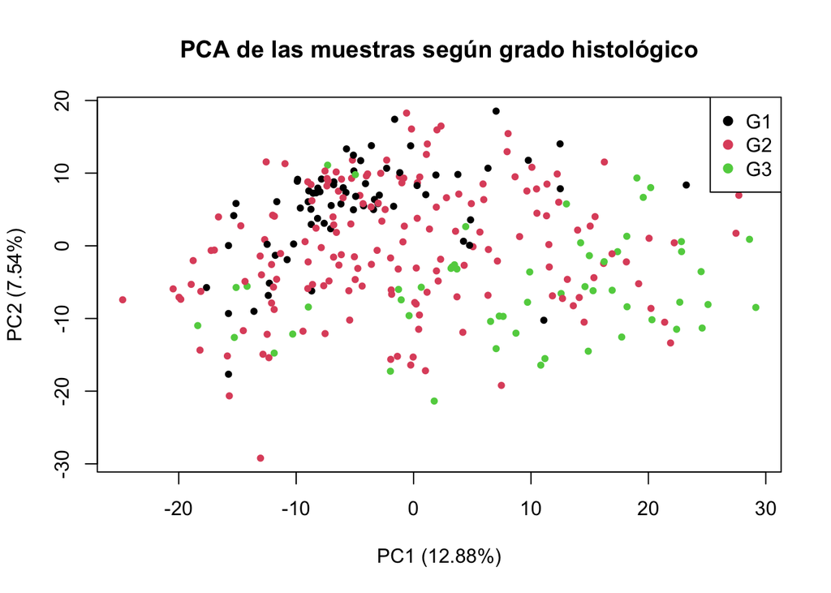

```r
# Representamos el PCA en función del grado histológico
plot(
  pca$x[, 1],
  pca$x[, 2],
  col = as.numeric(grade),
  pch = 20,
  xlab = paste0("PC1 (", var_exp[1], "%)"),
  ylab = paste0("PC2 (", var_exp[2], "%)"),
  main = "PCA de las muestras según grado histológico"
)

legend(
  "topright",
  legend = levels(grade),
  col = 1:3,
  pch = 19
)
```

El PCA no muestra una separación completa entre los tres grados histológicos, lo que indica que la variabilidad global de la expresión no permite distinguir claramente las clases mediante las dos primeras componentes principales. No obstante, se observa cierto solapamiento entre grados, especialmente en el grado 2, que presenta un comportamiento más heterogéneo. Este patrón es coherente con el carácter intermedio del grado histológico 2, mientras que los grados histológicos 1 y 3 sí que están más diferenciados.

# Filtrado no supervisado por correlación

Antes de aplicar los métodos de selección de características, se realiza un filtrado no supervisado para reducir la redundancia entre variables. En este paso se calcula la matriz de correlación entre probesets utilizando únicamente el conjunto de train. Posteriormente, se eliminan aquellos probesets que presentan una correlación elevada con otros, ya que aportan información muy similar y pueden aumentar innecesariamente la complejidad del modelo.

El filtrado se calcula solo sobre el conjunto de train y después se aplica el mismo conjunto de probesets seleccionados al conjunto de test y al conjunto de validación externa. De esta forma, se evita utilizar información procedente de los conjuntos de evaluación durante el preprocesamiento.

```r
corr_cutoff <- 0.90

# Calculamos la matriz de correlación entre probesets en entrenamiento
cor_matrix <- cor(expr_train)

# Identificamos los probesets altamente correlacionados
high_corr <- findCorrelation(
  cor_matrix,
  cutoff = corr_cutoff,
  names = TRUE
)

# Comprobamos el número de probesets eliminados
length(high_corr)
```

```
## [1] 489
```

```r
# Filtramos el conjunto de entrenamiento
expr_train_corr <- expr_train[, !colnames(expr_train) %in% high_corr, drop = FALSE]

# Aplicamos el mismo filtrado al conjunto de prueba interna
expr_test_corr <- expr_test[, colnames(expr_train_corr), drop = FALSE]

# Aplicamos el mismo filtrado al conjunto de validación externa
expr_validacion_externa_corr <- expr_validacion_externa[, colnames(expr_train_corr), drop = FALSE]

# Comprobamos las dimensiones después del filtrado
dim(expr_train_corr)
```

```
## [1]   204 21794
```

```r
dim(expr_test_corr)
```

```
## [1]    85 21794
```

```r
dim(expr_validacion_externa_corr)
```

```
## [1]   172 21794
```

El filtrado no supervisado por correlación elimina **489 probesets** que presentaban una correlación elevada con otros probesets del conjunto de entrenamiento. Tras aplicar este filtro, los tres conjuntos mantienen las mismas variables. Por una parte, el conjunto de train queda formado por **204 muestras** y **21.794 probesets**, el conjunto de test por **85 muestras** y **21.794 probesets**, y el conjunto de validación externa por **172 muestras** y **21.794 probesets**.

# **Selección de *probesets***

Los datos de microarrays se caracterizan por presentar una dimensionalidad muy elevada, es decir, presentan miles de variables frente a un número reducido de muestras. Esta situación puede dificultar el entrenamiento de modelos predictivos, aumentar el coste computacional y favorecer el sobreajuste. Por ello, la selección de variables constituye una etapa fundamental en este tipo de análisis, ya que permite reducir el número de *probesets* conservando aquellos con mayor interés para la clasificación.

En este trabajo, la selección de *probesets* se realiza únicamente sobre el conjunto de train. De esta forma, el conjunto de test permanece independiente y no participa en ninguna decisión relacionada con la selección de variables. Para facilitar la comparación entre métodos, se seleccionan los 100 probesets mejor posicionados por cada técnica, utilizando el criterio de ordenación propio de cada una de ellas.

Se comparan distintas familias de métodos de selección de variables descritas habitualmente en el análisis de datos de microarrays: métodos *filter*, métodos *embedded*, métodos *wrapper*, métodos **híbridos** y enfoques *ensemble*. Esta clasificación permite evaluar estrategias con distintos criterios de selección, desde métodos basados en medidas estadísticas independientes del clasificador hasta aproximaciones que incorporan el modelo predictivo dentro del propio proceso de selección.

## **Métodos *filter***

Los métodos *filter* seleccionan variables a partir de propiedades de los datos, sin depender directamente de un clasificador concreto. En general, asignan una puntuación o medida de relevancia a cada variable y utilizan ese criterio para ordenar o seleccionar los *probesets* más informativos.

### ANOVA

Dado que el análisis ANOVA (análisis de la varianza) se aplica de forma univariante independiente a miles de probesets, se genera un problema de comparaciones múltiples. Para controlar este efecto, se ajustan los p-valores mediante el método de Benjamini-Hochberg, que permite controlar la tasa de falsos descubrimientos (*False Discovery Rate*, FDR). Esta corrección resulta especialmente adecuada en estudios de expresión génica, ya que métodos más conservadores, como Bonferroni, pueden reducir excesivamente el número de probesets seleccionados.

En este caso, para cada probeset se plantea una hipótesis nula y una hipótesis alternativa. La hipótesis nula (H0) establece que la expresión media del probeset es igual en los tres grados histológicos, es decir, que no existen diferencias relevantes entre G1, G2 y G3. Por el contrario, la hipótesis alternativa (H1) indica que al menos uno de los grados presenta una expresión media diferente. De esta forma, ANOVA permite identificar aquellos probesets cuya expresión varía en función del grado histológico y que, por tanto, pueden resultar útiles para la clasificación posterior.

```r
# Definimos el número de probesets que seleccionamos
top_n_features <- 100

# Calculamos el p-valor de ANOVA para cada probeset en el conjunto de entrenamiento
anova_pvalues <- apply(expr_train_corr, 2, function(x) {
  modelo_anova <- summary(aov(x ~ grade_train))[[1]]
  modelo_anova[["Pr(>F)"]][1]
})

# Creamos una tabla con los resultados de ANOVA
tabla_anova <- data.frame(
  probeset = names(anova_pvalues),
  p_value = anova_pvalues
)

# Ajustamos los p-valores por comparaciones múltiples mediante Benjamini-Hochberg
tabla_anova$p_adj_BH <- p.adjust(
  tabla_anova$p_value,
  method = "BH"
)

# Ordenamos los probesets según el p-valor ajustado
tabla_anova <- tabla_anova[order(tabla_anova$p_adj_BH), ]

# Seleccionamos los probesets con menor p-valor ajustado
ps_anova_100 <- head(tabla_anova$probeset, top_n_features)

# Comprobamos el número de probesets seleccionados
length(ps_anova_100)
```

```
## [1] 100
```

### **mRMR**

mRMR (*minimum Redundancy Maximum Relevance*) es un método *filter* multivariante orientado a identificar variables con máxima relevancia y mínima redundancia en datos de alta dimensionalidad. A diferencia de ANOVA, no solo busca probesets relacionados con el grado histológico, sino que también intenta reducir la redundancia entre las variables seleccionadas. De esta forma, prioriza subconjuntos de probesets que aporten información relevante para la clasificación, evitando seleccionar variables excesivamente similares entre sí.

Al igual que en el caso anterior, la selección se realiza únicamente sobre el conjunto de entrenamiento. Finalmente, se conservan los 100 probesets mejor posicionados por el método.

```r
# Preparamos la variable objetivo en formato numérico para mRMR
grade_train_num <- as.numeric(grade_train)

# Creamos el data frame de entrada para mRMR
datos_mrmr <- data.frame(
  grado = grade_train_num,
  expr_train_corr,
  check.names = FALSE
)

# Convertimos los datos al formato requerido por mRMRe
datos_mrmr <- mRMR.data(data = datos_mrmr)

# Aplicamos mRMR sobre el conjunto de entrenamiento
modelo_mrmr <- mRMR.classic(
  data = datos_mrmr,
  target_indices = 1,
  feature_count = top_n_features
)

# Obtenemos los índices de los probesets seleccionados
idx_mrmr <- solutions(modelo_mrmr)[[1]]

# Obtenemos los nombres de los probesets seleccionados
ps_mrmr_100 <- featureNames(datos_mrmr)[idx_mrmr]

# Comprobamos el número de probesets seleccionados
length(ps_mrmr_100)
```

```
## [1] 100
```

En los dos métodos *filter* aplicados se obtiene un conjunto final de **100 probesets** seleccionados a partir del conjunto de train.

## **Métodos *embedded***

Los métodos *embedded* integran la selección de variables dentro del propio proceso de aprendizaje del modelo. A diferencia de los métodos *filter*, no se basan únicamente en una medida estadística externa, sino que identifican los *probesets* relevantes mientras se ajusta el modelo. Utilizan el núcleo del algoritmo de aprendizaje para valorar la importancia de las variables, un ejemplo de estos métodos son LASSO y SVM-RFE.

### LASSO

El método LASSO (*Least Absolute Shrinkage and Selection Operator*) ajusta un modelo multinomial penalizado mediante regularización L1, lo que favorece que algunos coeficientes se reduzcan exactamente a cero. De este modo, los *probesets* con coeficientes distintos de cero se consideran variables seleccionadas por el modelo. En este caso, al tratarse de un problema multiclase, cada *probeset* puede tener coeficientes asociados a las distintas clases. Por ello, en este análisis se resume la importancia de cada *probeset* mediante el valor absoluto máximo de sus coeficientes entre clases, generando un ranking final del que se seleccionan los primeros 100 *probesets,* si llegan.

```r
# Preparamos la matriz de expresión para LASSO
x_lasso <- as.matrix(expr_train_corr)

# Preparamos la variable objetivo para LASSO
y_lasso <- grade_train

# Ajustamos un modelo LASSO multinomial con validación cruzada
set.seed(seed)
modelo_lasso <- cv.glmnet(
  x = x_lasso,
  y = y_lasso,
  family = "multinomial",
  alpha = 1,
  type.measure = "class",
  nfolds = 5
)

# Obtenemos los coeficientes del modelo con lambda mínimo
coef_lasso <- coef(modelo_lasso, s = "lambda.min")

# Unimos los coeficientes de las tres clases en una matriz
coef_lasso_mat <- do.call(
  cbind,
  lapply(coef_lasso, function(x) as.numeric(x[, 1]))
)

# Asignamos los nombres de los probesets a la matriz de coeficientes
rownames(coef_lasso_mat) <- rownames(coef_lasso[[1]])

# Eliminamos los iguales
coef_lasso_mat <- coef_lasso_mat[rownames(coef_lasso_mat) != "(Intercept)", , drop = FALSE]

# Calculamos la importancia de cada probeset como el coeficiente absoluto máximo
importancia_lasso <- apply(abs(coef_lasso_mat), 1, max)

# Creamos una tabla con los resultados de LASSO
tabla_lasso <- data.frame(
  probeset = names(importancia_lasso),
  importancia = importancia_lasso
)

# Conservamos únicamente los probesets con coeficiente distinto de cero
tabla_lasso <- tabla_lasso[tabla_lasso$importancia > 0, ]

# Ordenamos los probesets según su importancia
tabla_lasso <- tabla_lasso[order(tabla_lasso$importancia, decreasing = TRUE), ]

# Seleccionamos los 100 probesets más relevantes según LASSO
ps_lasso_100 <- head(tabla_lasso$probeset, top_n_features)

# Comprobamos el número de probesets seleccionados
length(ps_lasso_100)
```

```
## [1] 70
```

### SVM-RFE

SVM-RFE (*Support Vector Machine Recursive Feature Elimination*) se aplica como método *embedded* basado en SVM. Este procedimiento elimina variables de forma recursiva, conservando aquellas que resultan más relevantes para el modelo durante el proceso de clasificación. A diferencia de los métodos *filter*, SVM-RFE incorpora el modelo predictivo dentro del propio proceso de selección, por lo que la importancia de cada probeset se evalúa en función de su contribución al clasificador.

En este trabajo se evalúan dos variantes del método: una con kernel lineal y otra con kernel radial. El objetivo es comparar si la selección de probesets cambia en función del tipo de frontera de decisión utilizada por el modelo.

A diferencia de métodos como ANOVA o mRMR, que generan un ranking de variables sobre el que se aplica un corte fijo, en SVM-RFE no se fija directamente un número final de probesets. En este caso, se evalúan distintos tamaños de firma génica mediante validación cruzada interna dentro del conjunto de train. De esta forma, el número final de probesets seleccionados viene determinado por el tamaño que obtiene el mejor rendimiento durante este proceso.

Dado el elevado número de probesets, antes de aplicar SVM-RFE se realiza un prefiltrado no supervisado por varianza dentro del conjunto de train. Este paso permite reducir el coste computacional del procedimiento, conservando los probesets con mayor variabilidad sin utilizar información del conjunto de test ni de la validación externa.

```r
# Definimos el número de probesets que mantenemos en el prefiltrado de SVM-RFE
top_n_rfe_prefiltro <- 2000

# Definimos el número máximo de probesets que permitimos seleccionar
max_features_rfe <- 100

# Calculamos la varianza de cada probeset en el conjunto de entrenamiento
var_rfe <- apply(expr_train_corr, 2, var)

# Seleccionamos los probesets con mayor varianza
ps_rfe_prefiltro <- names(
  sort(var_rfe, decreasing = TRUE)
)[1:top_n_rfe_prefiltro]

# Filtramos el conjunto de entrenamiento para aplicar SVM-RFE
expr_train_rfe_pref <- expr_train_corr[, ps_rfe_prefiltro, drop = FALSE]

# Definimos los tamaños de firma génica que evaluamos con SVM-RFE
sizes_rfe <- c(5, 10, 20, 30, 50, 100)

# Nos aseguramos de que ningún tamaño supera el máximo permitido
sizes_rfe <- sizes_rfe[sizes_rfe <= max_features_rfe]

# Definimos el control de validación cruzada interna para SVM-RFE
ctrl_rfe <- rfeControl(
  functions = caretFuncs,
  method = "cv",
  number = 5,
  verbose = FALSE
)
```

```r
# Aplicamos SVM-RFE con kernel lineal sobre el conjunto de entrenamiento
set.seed(seed)

modelo_svmrfe_lineal <- rfe(
  x = expr_train_rfe_pref,
  y = grade_train,
  sizes = sizes_rfe,
  rfeControl = ctrl_rfe,
  method = "svmLinear",
  metric = "Accuracy",
  preProcess = c("center", "scale"),
  tuneLength = 3
)

# Seleccionamos únicamente los resultados con un máximo de 100 probesets
resultados_lineal_validos <- modelo_svmrfe_lineal$results[
  modelo_svmrfe_lineal$results$Variables <= max_features_rfe,
]

# Obtenemos el tamaño con mejor Accuracy dentro de los tamaños permitidos
mejor_size_svmrfe_lineal <- resultados_lineal_validos$Variables[
  which.max(resultados_lineal_validos$Accuracy)
]

# Extraemos el ranking de variables correspondiente al tamaño seleccionado
ranking_lineal <- modelo_svmrfe_lineal$variables[
  modelo_svmrfe_lineal$variables$Variables == mejor_size_svmrfe_lineal,
]

# Calculamos la importancia media de cada probeset entre particiones
ranking_lineal_resumen <- aggregate(
  Overall ~ var,
  data = ranking_lineal,
  FUN = mean
)

# Ordenamos los probesets según su importancia
ranking_lineal_resumen <- ranking_lineal_resumen[
  order(ranking_lineal_resumen$Overall, decreasing = TRUE),
]

# Obtenemos los probesets seleccionados por SVM-RFE lineal
ps_svmrfe_lineal <- head(
  ranking_lineal_resumen$var,
  mejor_size_svmrfe_lineal
)

# Comprobamos el número de probesets seleccionados
length(ps_svmrfe_lineal)
```

```
## [1] 100
```

```r
# Aplicamos SVM-RFE con kernel radial sobre el conjunto de entrenamiento
set.seed(seed)

modelo_svmrfe_radial <- rfe(
  x = expr_train_rfe_pref,
  y = grade_train,
  sizes = sizes_rfe,
  rfeControl = ctrl_rfe,
  method = "svmRadial",
  metric = "Accuracy",
  preProcess = c("center", "scale"),
  tuneLength = 3
)

# Seleccionamos únicamente los resultados con un máximo de 100 probesets
resultados_radial_validos <- modelo_svmrfe_radial$results[
  modelo_svmrfe_radial$results$Variables <= max_features_rfe,
]

# Obtenemos el tamaño con mejor Accuracy dentro de los tamaños permitidos
mejor_size_svmrfe_radial <- resultados_radial_validos$Variables[
  which.max(resultados_radial_validos$Accuracy)
]

# Extraemos el ranking de variables correspondiente al tamaño seleccionado
ranking_radial <- modelo_svmrfe_radial$variables[
  modelo_svmrfe_radial$variables$Variables == mejor_size_svmrfe_radial,
]

# Calculamos la importancia media de cada probeset entre particiones
ranking_radial_resumen <- aggregate(
  Overall ~ var,
  data = ranking_radial,
  FUN = mean
)

# Ordenamos los probesets según su importancia
ranking_radial_resumen <- ranking_radial_resumen[
  order(ranking_radial_resumen$Overall, decreasing = TRUE),
]

# Obtenemos los probesets seleccionados por SVM-RFE radial
ps_svmrfe_radial <- head(
  ranking_radial_resumen$var,
  mejor_size_svmrfe_radial
)

# Comprobamos el número de probesets seleccionados
length(ps_svmrfe_radial)
```

```
## [1] 100
```

En los métodos *embedded* aplicados, el número final de probesets seleccionados depende del propio proceso de ajuste de cada modelo. En el caso de LASSO, se obtiene un conjunto final de **70 probesets**. Por otro lado, SVM-RFE con kernel lineal y SVM-RFE con kernel radial seleccionan **100 probesets** cada uno.

## **Métodos híbridos**

Los métodos híbridos combinan dos estrategias de selección de variables en etapas sucesivas. En primer lugar, se aplica un método de reducción inicial para obtener un subconjunto de *probesets* candidatos. Posteriormente, sobre ese subconjunto reducido se aplica un segundo método de selección más específico.

En este trabajo se combinan los métodos *filter* previamente utilizados, ANOVA y mRMR, con métodos *embedded*, LASSO multinomial y SVM-RFE. De esta forma, los métodos *filter* actúan como una primera etapa de reducción de dimensionalidad, mientras que LASSO y SVM-RFE refinan la selección final de *probesets*.

```r
# Partimos (primera etapa) de los seleccionados previamente por ANOVA y mRMR
expr_train_anova_100 <- expr_train_corr[, ps_anova_100, drop = FALSE]
expr_train_mrmr_100  <- expr_train_corr[, ps_mrmr_100, drop = FALSE]
```

### ANOVA + LASSO

```r
# Preparamos la matriz de entrenamiento para ANOVA + LASSO
x_anova_lasso <- as.matrix(expr_train_anova_100)

# Preparamos la variable objetivo
y_anova_lasso <- grade_train

# Ajustamos un modelo LASSO sobre los probesets seleccionados por ANOVA
set.seed(seed)
modelo_anova_lasso <- cv.glmnet(
  x = x_anova_lasso,
  y = y_anova_lasso,
  family = "multinomial",
  alpha = 1,
  type.measure = "class",
  nfolds = 5
)

# Obtenemos los coeficientes del modelo con lambda mínimo
coef_anova_lasso <- coef(
  modelo_anova_lasso,
  s = "lambda.min"
)

# Unimos los coeficientes de las tres clases en una matriz
coef_anova_lasso_mat <- do.call(
  cbind,
  lapply(coef_anova_lasso, function(x) as.numeric(x[, 1]))
)

# Asignamos los nombres de los probesets a la matriz de coeficientes
rownames(coef_anova_lasso_mat) <- rownames(coef_anova_lasso[[1]])

# Eliminamos el intercepto, ya que no corresponde a ningún probeset
coef_anova_lasso_mat <- coef_anova_lasso_mat[
  rownames(coef_anova_lasso_mat) != "(Intercept)", , drop = FALSE]

# Calculamos la importancia de cada probeset como el coeficiente absoluto máximo
importancia_anova_lasso <- apply(
  abs(coef_anova_lasso_mat), 1, max)

# Creamos una tabla con los resultados de ANOVA + LASSO
tabla_anova_lasso <- data.frame(
  probeset = names(importancia_anova_lasso),
  importancia = importancia_anova_lasso
)

# Conservamos únicamente los probesets con coeficiente distinto de cero
tabla_anova_lasso <- tabla_anova_lasso[
  tabla_anova_lasso$importancia > 0,
]

# Ordenamos los probesets según su importancia
tabla_anova_lasso <- tabla_anova_lasso[
  order(tabla_anova_lasso$importancia, decreasing = TRUE),
]

# Seleccionamos los probesets finales de ANOVA + LASSO
ps_anova_lasso <- head(
  tabla_anova_lasso$probeset,
  top_n_features
)

# Comprobamos el número de probesets seleccionados
length(ps_anova_lasso)
```

```
## [1] 34
```

### ANOVA + SVM-RFE lineal

```r
# Definimos los tamaños de firma génica que evaluamos en ANOVA + SVM-RFE lineal
sizes_anova_svmrfe <- sizes_rfe[
  sizes_rfe <= ncol(expr_train_anova_100)
]

# Aplicamos SVM-RFE lineal sobre los probesets seleccionados por ANOVA
set.seed(seed)

modelo_anova_svmrfe_lineal <- rfe(
  x = expr_train_anova_100,
  y = grade_train,
  sizes = sizes_anova_svmrfe,
  rfeControl = ctrl_rfe,
  method = "svmLinear",
  metric = "Accuracy",
  preProcess = c("center", "scale"),
  tuneLength = 3
)

# Seleccionamos únicamente los resultados con un máximo de 100 probesets
resultados_anova_svmrfe_lineal_validos <- modelo_anova_svmrfe_lineal$results[
  modelo_anova_svmrfe_lineal$results$Variables <= max_features_rfe,
]

# Obtenemos el tamaño con mejor Accuracy dentro de los tamaños permitidos
mejor_size_anova_svmrfe_lineal <- resultados_anova_svmrfe_lineal_validos$Variables[
  which.max(resultados_anova_svmrfe_lineal_validos$Accuracy)
]

# Extraemos el ranking de variables correspondiente al tamaño seleccionado
ranking_anova_svmrfe_lineal <- modelo_anova_svmrfe_lineal$variables[
  modelo_anova_svmrfe_lineal$variables$Variables == mejor_size_anova_svmrfe_lineal,
]

# Calculamos la importancia media de cada probeset entre particiones
ranking_anova_svmrfe_lineal_resumen <- aggregate(
  Overall ~ var,
  data = ranking_anova_svmrfe_lineal,
  FUN = mean
)

# Ordenamos los probesets según su importancia
ranking_anova_svmrfe_lineal_resumen <- ranking_anova_svmrfe_lineal_resumen[
  order(ranking_anova_svmrfe_lineal_resumen$Overall, decreasing = TRUE),
]

# Obtenemos los probesets seleccionados por ANOVA + SVM-RFE lineal
ps_anova_svmrfe_lineal <- head(
  ranking_anova_svmrfe_lineal_resumen$var,
  mejor_size_anova_svmrfe_lineal
)

# Comprobamos el número de probesets seleccionados
length(ps_anova_svmrfe_lineal)
```

```
## [1] 100
```

### ANOVA + SVM-RFE radial

```r
# Definimos los tamaños de firma génica que evaluamos en ANOVA + SVM-RFE radial
sizes_anova_svmrfe <- sizes_rfe[
  sizes_rfe <= ncol(expr_train_anova_100)
]

# Aplicamos SVM-RFE radial sobre los probesets seleccionados por ANOVA
set.seed(seed)

modelo_anova_svmrfe_radial <- rfe(
  x = expr_train_anova_100,
  y = grade_train,
  sizes = sizes_anova_svmrfe,
  rfeControl = ctrl_rfe,
  method = "svmRadial",
  metric = "Accuracy",
  preProcess = c("center", "scale"),
  tuneLength = 3
)

# Seleccionamos únicamente los resultados con un máximo de 100 probesets
resultados_anova_svmrfe_radial_validos <- modelo_anova_svmrfe_radial$results[
  modelo_anova_svmrfe_radial$results$Variables <= max_features_rfe,
]

# Obtenemos el tamaño con mejor Accuracy dentro de los tamaños permitidos
mejor_size_anova_svmrfe_radial <- resultados_anova_svmrfe_radial_validos$Variables[
  which.max(resultados_anova_svmrfe_radial_validos$Accuracy)
]

# Extraemos el ranking de variables correspondiente al tamaño seleccionado
ranking_anova_svmrfe_radial <- modelo_anova_svmrfe_radial$variables[
  modelo_anova_svmrfe_radial$variables$Variables == mejor_size_anova_svmrfe_radial,
]

# Calculamos la importancia media de cada probeset entre particiones
ranking_anova_svmrfe_radial_resumen <- aggregate(
  Overall ~ var,
  data = ranking_anova_svmrfe_radial,
  FUN = mean
)

# Ordenamos los probesets según su importancia
ranking_anova_svmrfe_radial_resumen <- ranking_anova_svmrfe_radial_resumen[
  order(ranking_anova_svmrfe_radial_resumen$Overall, decreasing = TRUE),
]

# Obtenemos los probesets seleccionados por ANOVA + SVM-RFE radial
ps_anova_svmrfe_radial <- head(
  ranking_anova_svmrfe_radial_resumen$var,
  mejor_size_anova_svmrfe_radial
)

# Comprobamos el número de probesets seleccionados
length(ps_anova_svmrfe_radial)
```

```
## [1] 100
```

En las combinaciones híbridas que parten de ANOVA se obtienen firmas génicas de distinto tamaño. La combinación **ANOVA + LASSO** reduce el conjunto inicial de 100 probesets a **34 probesets**. Por otro lado, las combinaciones **ANOVA + SVM-RFE lineal** y **ANOVA + SVM-RFE radial** seleccionan **100 probesets** cada una.

### mRMR + LASSO

```r
# Preparamos la matriz de entrenamiento para mRMR + LASSO
x_mrmr_lasso <- as.matrix(expr_train_mrmr_100)

# Preparamos la variable objetivo
y_mrmr_lasso <- grade_train

# Ajustamos un modelo LASSO multinomial sobre los probesets seleccionados por mRMR
set.seed(seed)
modelo_mrmr_lasso <- cv.glmnet(
  x = x_mrmr_lasso,
  y = y_mrmr_lasso,
  family = "multinomial",
  alpha = 1,
  type.measure = "class",
  nfolds = 5
)

# Obtenemos los coeficientes del modelo con lambda mínimo
coef_mrmr_lasso <- coef(
  modelo_mrmr_lasso,
  s = "lambda.min"
)

# Unimos los coeficientes de las tres clases en una matriz
coef_mrmr_lasso_mat <- do.call(
  cbind,
  lapply(coef_mrmr_lasso, function(x) as.numeric(x[, 1]))
)

# Asignamos los nombres de los probesets a la matriz de coeficientes
rownames(coef_mrmr_lasso_mat) <- rownames(coef_mrmr_lasso[[1]])

# Eliminamos el intercepto, ya que no corresponde a ningún probeset
coef_mrmr_lasso_mat <- coef_mrmr_lasso_mat[
  rownames(coef_mrmr_lasso_mat) != "(Intercept)", , drop = FALSE
]

# Calculamos la importancia de cada probeset como el coeficiente absoluto máximo
importancia_mrmr_lasso <- apply(
  abs(coef_mrmr_lasso_mat), 1, max
)

# Creamos una tabla con los resultados de mRMR + LASSO
tabla_mrmr_lasso <- data.frame(
  probeset = names(importancia_mrmr_lasso),
  importancia = importancia_mrmr_lasso
)

# Conservamos únicamente los probesets con coeficiente distinto de cero
tabla_mrmr_lasso <- tabla_mrmr_lasso[
  tabla_mrmr_lasso$importancia > 0,
]

# Ordenamos los probesets según su importancia
tabla_mrmr_lasso <- tabla_mrmr_lasso[
  order(tabla_mrmr_lasso$importancia, decreasing = TRUE),
]

# Obtenemos los probesets seleccionados por mRMR + LASSO
ps_mrmr_lasso <- head(
  tabla_mrmr_lasso$probeset,
  top_n_features
)

# Comprobamos el número de probesets seleccionados
length(ps_mrmr_lasso)
```

```
## [1] 59
```

### mRMR + SVM-RFE lineal

```r
# Definimos los tamaños de firma génica que evaluamos en mRMR + SVM-RFE lineal
sizes_mrmr_svmrfe <- sizes_rfe[
  sizes_rfe <= ncol(expr_train_mrmr_100)
]

# Aplicamos SVM-RFE lineal sobre los probesets seleccionados por mRMR
set.seed(seed)
modelo_mrmr_svmrfe_lineal <- rfe(
  x = expr_train_mrmr_100,
  y = grade_train,
  sizes = sizes_mrmr_svmrfe,
  rfeControl = ctrl_rfe,
  method = "svmLinear",
  metric = "Accuracy",
  preProcess = c("center", "scale"),
  tuneLength = 3
)

# Seleccionamos únicamente los resultados con un máximo de 100 probesets
resultados_mrmr_svmrfe_lineal_validos <- modelo_mrmr_svmrfe_lineal$results[
  modelo_mrmr_svmrfe_lineal$results$Variables <= max_features_rfe,
]

# Obtenemos el tamaño con mejor Accuracy dentro de los tamaños permitidos
mejor_size_mrmr_svmrfe_lineal <- resultados_mrmr_svmrfe_lineal_validos$Variables[
  which.max(resultados_mrmr_svmrfe_lineal_validos$Accuracy)
]

# Extraemos el ranking de variables correspondiente al tamaño seleccionado
ranking_mrmr_svmrfe_lineal <- modelo_mrmr_svmrfe_lineal$variables[
  modelo_mrmr_svmrfe_lineal$variables$Variables == mejor_size_mrmr_svmrfe_lineal,
]

# Calculamos la importancia media de cada probeset entre particiones
ranking_mrmr_svmrfe_lineal_resumen <- aggregate(
  Overall ~ var,
  data = ranking_mrmr_svmrfe_lineal,
  FUN = mean
)

# Ordenamos los probesets según su importancia
ranking_mrmr_svmrfe_lineal_resumen <- ranking_mrmr_svmrfe_lineal_resumen[
  order(ranking_mrmr_svmrfe_lineal_resumen$Overall, decreasing = TRUE),
]

# Obtenemos los probesets seleccionados por mRMR + SVM-RFE lineal
ps_mrmr_svmrfe_lineal <- head(
  ranking_mrmr_svmrfe_lineal_resumen$var,
  mejor_size_mrmr_svmrfe_lineal
)

# Comprobamos el número de probesets seleccionados
length(ps_mrmr_svmrfe_lineal)
```

```
## [1] 10
```

### mRMR + SVM-RFE radial

```r
# Definimos los tamaños de firma génica que evaluamos en mRMR + SVM-RFE radial
sizes_mrmr_svmrfe <- sizes_rfe[
  sizes_rfe <= ncol(expr_train_mrmr_100)
]

# Aplicamos SVM-RFE radial sobre los probesets seleccionados por mRMR
set.seed(seed)
modelo_mrmr_svmrfe_radial <- rfe(
  x = expr_train_mrmr_100,
  y = grade_train,
  sizes = sizes_mrmr_svmrfe,
  rfeControl = ctrl_rfe,
  method = "svmRadial",
  metric = "Accuracy",
  preProcess = c("center", "scale"),
  tuneLength = 3
)

# Seleccionamos únicamente los resultados con un máximo de 100 probesets
resultados_mrmr_svmrfe_radial_validos <- modelo_mrmr_svmrfe_radial$results[
  modelo_mrmr_svmrfe_radial$results$Variables <= max_features_rfe,
]

# Obtenemos el tamaño con mejor Accuracy dentro de los tamaños permitidos
mejor_size_mrmr_svmrfe_radial <- resultados_mrmr_svmrfe_radial_validos$Variables[
  which.max(resultados_mrmr_svmrfe_radial_validos$Accuracy)
]

# Extraemos el ranking de variables correspondiente al tamaño seleccionado
ranking_mrmr_svmrfe_radial <- modelo_mrmr_svmrfe_radial$variables[
  modelo_mrmr_svmrfe_radial$variables$Variables == mejor_size_mrmr_svmrfe_radial,
]

# Calculamos la importancia media de cada probeset entre particiones
ranking_mrmr_svmrfe_radial_resumen <- aggregate(
  Overall ~ var,
  data = ranking_mrmr_svmrfe_radial,
  FUN = mean
)

# Ordenamos los probesets según su importancia
ranking_mrmr_svmrfe_radial_resumen <- ranking_mrmr_svmrfe_radial_resumen[
  order(ranking_mrmr_svmrfe_radial_resumen$Overall, decreasing = TRUE),
]

# Obtenemos los probesets seleccionados por mRMR + SVM-RFE radial
ps_mrmr_svmrfe_radial <- head(
  ranking_mrmr_svmrfe_radial_resumen$var,
  mejor_size_mrmr_svmrfe_radial
)

# Comprobamos el número de probesets seleccionados
length(ps_mrmr_svmrfe_radial)
```

```
## [1] 100
```

En las combinaciones híbridas que parten de mRMR se obtienen firmas génicas de distinto tamaño. La combinación **mRMR + LASSO** selecciona **59 probesets**, **mRMR + SVM-RFE lineal** selecciona **10 probesets** y **mRMR + SVM-RFE radial** selecciona **100 probesets**.

## Métodos *ensemble*

Finalmente, se construye una selección *ensemble* a partir de los probesets obtenidos por los métodos anteriores. Esta estrategia busca identificar probesets seleccionados de forma recurrente por distintas técnicas, asumiendo que aquellos que aparecen en varios métodos pueden representar variables más robustas para la clasificación. Para ello, se agrupan todos los subconjuntos de probesets generados, se calcula cuántas veces aparece cada probeset y se seleccionan los probesets que se repiten más de 3 o 4 veces, en este caso.

Además, no se incluyen en el *ensemble* las combinaciones híbridas que vuelven a seleccionar los 100 probesets de partida, ya que en estos casos no se produce una reducción adicional de la firma inicial. De esta forma, se evita sobrerrepresentar métodos que no aportan una selección diferencial respecto a su primera etapa.

```r
# Juntamos en una lista los conjuntos de probesets que mantenemos para el ensemble
lista_metodos_ensemble <- list(
  ANOVA = ps_anova_100,
  mRMR = ps_mrmr_100,
  LASSO = ps_lasso_100,
  SVM_RFE_lineal = ps_svmrfe_lineal,
  SVM_RFE_radial = ps_svmrfe_radial,
  ANOVA_LASSO = ps_anova_lasso,
  mRMR_LASSO = ps_mrmr_lasso,
  mRMR_SVM_RFE_lineal = ps_mrmr_svmrfe_lineal
)

# Nos aseguramos de que cada método aporte cada probeset una sola vez
lista_metodos_ensemble <- lapply(lista_metodos_ensemble, unique)

# Unimos todos los probesets seleccionados en un único vector
todos_los_probesets <- unlist(lista_metodos_ensemble)

# Calculamos cuántas veces aparece cada probeset entre los distintos métodos
frecuencia_probesets <- sort(
  table(todos_los_probesets),
  decreasing = TRUE
)

# Seleccionamos los probesets que aparecen en al menos cuatro métodos
ps_ensemble_4votos <- names(
  frecuencia_probesets[frecuencia_probesets >= 4]
)

# Seleccionamos los probesets que aparecen en al menos tres métodos
ps_ensemble_3votos <- names(
  frecuencia_probesets[frecuencia_probesets >= 3]
)

# Comprobamos el número de probesets seleccionados por cada ensemble
length(ps_ensemble_4votos)
```

```
## [1] 21
```

```r
length(ps_ensemble_3votos)
```

```
## [1] 71
```

```r
# Creamos una tabla resumen de frecuencias
tabla_ensemble <- data.frame(
  probeset = names(frecuencia_probesets),
  frecuencia = as.numeric(frecuencia_probesets)
)
```

Como resultado del enfoque *ensemble*, se obtienen dos firmas candidatas. La primera, formada por los probesets presentes en al menos **cuatro métodos**, incluye **21 probesets**. La segunda, menos restrictiva, considera los probesets presentes en al menos **tres métodos** y está formada por **71 probesets**.

# **Clasificación supervisada**

En esta fase se comparan varios clasificadores sobre cada conjunto de probesets seleccionado. SMOTE se aplica dentro de la validación cruzada mediante `trainControl(sampling = "smote")`. De esta forma, las muestras sintéticas se generan únicamente dentro de los subconjuntos de entrenamiento de cada partición, sin modificar el conjunto de validación ni el conjunto de test.

```r
# Creamos la lista final de conjuntos de probesets para la clasificación
lista_probesets <- list(
  ANOVA = ps_anova_100,
  mRMR = ps_mrmr_100,
  LASSO = ps_lasso_100,
  SVM_RFE_lineal = ps_svmrfe_lineal,
  SVM_RFE_radial = ps_svmrfe_radial,
  ANOVA_LASSO = ps_anova_lasso,
  mRMR_LASSO = ps_mrmr_lasso,
  mRMR_SVM_RFE_lineal = ps_mrmr_svmrfe_lineal,
  Ensemble_4_votos = ps_ensemble_4votos,
  Ensemble_3_votos = ps_ensemble_3votos
)

# Definimos el grupo al que pertenece cada método
grupo_metodo <- c(
  ANOVA = "Filter",
  mRMR = "Filter",
  LASSO = "Embedded",
  SVM_RFE_lineal = "Embedded",
  SVM_RFE_radial = "Embedded",
  ANOVA_LASSO = "Hybrid",
  mRMR_LASSO = "Hybrid",
  mRMR_SVM_RFE_lineal = "Hybrid",
  Ensemble_4_votos = "Ensemble",
  Ensemble_3_votos = "Ensemble"
)

# Creamos una tabla resumen de las firmas de probesets
resumen_seleccion <- data.frame(
  metodo = names(lista_probesets),
  grupo = grupo_metodo[names(lista_probesets)],
  n_probesets = sapply(lista_probesets, length),
  row.names = NULL
)

# Mostramos el resumen de selección
resumen_seleccion
```

```
##                 metodo    grupo n_probesets
## 1                ANOVA   Filter         100
## 2                 mRMR   Filter         100
## 3                LASSO Embedded          70
## 4       SVM_RFE_lineal Embedded         100
## 5       SVM_RFE_radial Embedded         100
## 6          ANOVA_LASSO   Hybrid          34
## 7           mRMR_LASSO   Hybrid          59
## 8  mRMR_SVM_RFE_lineal   Hybrid          10
## 9     Ensemble_4_votos Ensemble          21
## 10    Ensemble_3_votos Ensemble          71
```

## Funciones auxiliares de clasificación

Antes de entrenar los modelos, se definen varias funciones auxiliares para automatizar el proceso de evaluación. Estas funciones permiten calcular métricas adicionales, como la Macro-F1, entrenar los distintos clasificadores bajo una misma estrategia de validación cruzada con SMOTE y evaluar posteriormente su rendimiento sobre el conjunto de test interno.

```r
# Función para calcular la Macro-F1 a partir de una matriz de confusión
macro_f1 <- function(cm) {

  # Convertimos la tabla de la matriz de confusión a formato matriz
  tab <- as.matrix(cm$table)

  # Obtenemos los nombres de las clases
  clases <- rownames(tab)

  # Calculamos el F1-score de cada clase por separado
  f1_por_clase <- sapply(seq_along(clases), function(i) {

    # Calculamos verdaderos positivos, falsos positivos y falsos negativos
    TP <- tab[i, i]
    FP <- sum(tab[i, ]) - TP
    FN <- sum(tab[, i]) - TP

    # Calculamos la precisión de la clase
    precision <- ifelse((TP + FP) == 0, 0, TP / (TP + FP))

    # Calculamos el recall o sensibilidad de la clase
    recall <- ifelse((TP + FN) == 0, 0, TP / (TP + FN))

    # Calculamos el F1-score de la clase
    if ((precision + recall) == 0) {
      return(0)
    } else {
      return(2 * precision * recall / (precision + recall))
    }
  })

  # Calculamos la media del F1-score de todas las clases
  mean(f1_por_clase)
}
```

```r
# Función para entrenar distintos modelos de clasificación
entrenar_modelo <- function(x_train, y_train, metodo, seed = 123) {

  # Definimos la validación cruzada repetida
  # Incluimos SMOTE dentro de la validación cruzada para balancear los folds de train
  ctrl <- trainControl(
    method = "repeatedcv",
    number = 5,
    repeats = 3,
    sampling = "smote",
    savePredictions = "final"
  )

  # Aseguramos que la variable respuesta tiene siempre los mismos niveles
  y_train <- factor(y_train, levels = c("G1", "G2", "G3"))

  # Convertimos los predictores a data frame
  x_train <- as.data.frame(x_train, check.names = FALSE)

  # Fijamos la semilla para hacer el entrenamiento reproducible
  set.seed(seed)

  # Entrenamos un SVM con kernel lineal
  if (metodo == "SVM_lineal") {
    modelo <- train(
      x = x_train,
      y = y_train,
      method = "svmLinear",
      trControl = ctrl,
      preProcess = c("center", "scale"),
      tuneLength = 5
    )
  }

  # Entrenamos un SVM con kernel radial
  else if (metodo == "SVM_radial") {
    modelo <- train(
      x = x_train,
      y = y_train,
      method = "svmRadial",
      trControl = ctrl,
      preProcess = c("center", "scale"),
      tuneLength = 5
    )
  }

  # Entrenamos un modelo KNN
  else if (metodo == "KNN") {
    modelo <- train(
      x = x_train,
      y = y_train,
      method = "knn",
      trControl = ctrl,
      preProcess = c("center", "scale"),
      tuneLength = 10
    )
  }

  # Entrenamos un Random Forest
  else if (metodo == "RF") {
    modelo <- train(
      x = x_train,
      y = y_train,
      method = "rf",
      trControl = ctrl,
      tuneLength = 5,
      ntree = 500
    )
  }

  # Entrenamos un modelo de análisis discriminante lineal
  else if (metodo == "LDA") {
    modelo <- train(
      x = x_train,
      y = y_train,
      method = "lda",
      trControl = ctrl,
      preProcess = c("center", "scale")
    )
  }

  # Devolvemos el modelo entrenado
  return(modelo)
}
```

```r
# Función para evaluar un modelo entrenado sobre el conjunto de test
evaluar_modelo <- function(modelo, x_test, y_test) {

  # Convertimos el conjunto test a data frame
  x_test <- as.data.frame(x_test, check.names = FALSE)

  # Aseguramos que la variable real del test tiene los mismos niveles
  y_test <- factor(y_test, levels = c("G1", "G2", "G3"))

  # Obtenemos las predicciones del modelo sobre el conjunto test
  pred <- predict(modelo, newdata = x_test)

  # Aseguramos que las predicciones tienen los mismos niveles que la variable real
  pred <- factor(pred, levels = c("G1", "G2", "G3"))

  # Calculamos la matriz de confusión
  cm <- confusionMatrix(pred, y_test)

  # Calculamos la Balanced Accuracy media entre clases ya que están desbalanceadas
  if (is.matrix(cm$byClass)) {
    bal_acc <- mean(cm$byClass[, "Balanced Accuracy"], na.rm = TRUE)
  } else {
    bal_acc <- unname(cm$byClass["Balanced Accuracy"])
  }

  # Calculamos la Macro-F1 usando la función definida anteriormente
  f1 <- macro_f1(cm)

  # Extraemos el rendimiento medio obtenido durante la validación cruzada
  perf_cv <- getTrainPerf(modelo)

  # Devolvemos las métricas principales del modelo
  data.frame(
    CV_Accuracy = perf_cv$TrainAccuracy,
    CV_Kappa = perf_cv$TrainKappa,
    Test_Accuracy = unname(cm$overall["Accuracy"]),
    Test_Kappa = unname(cm$overall["Kappa"]),
    Test_Balanced_Accuracy = bal_acc,
    Test_Macro_F1 = f1
  )
}
```

## Clasificación

```r
# Definimos los modelos de clasificación que vamos a comparar
modelos_a_probar <- c(
  "SVM_lineal",
  "SVM_radial",
  "KNN",
  "RF",
  "LDA"
)

# Creamos listas vacías para guardar los resultados y los modelos entrenados
resultados_lista <- list()
modelos_entrenados <- list()

# Creamos un contador para almacenar los resultados de cada combinación
contador <- 1

# Recorremos cada conjunto de probesets obtenido en la fase de selección
for (nombre_grupo in names(lista_probesets)) {

  # Extraemos los probesets correspondientes al grupo actual
  probesets_actuales <- lista_probesets[[nombre_grupo]]

  # Nos aseguramos de conservar solo probesets presentes en train y test filtrados
  probesets_actuales <- intersect(probesets_actuales, colnames(expr_train_corr))
  probesets_actuales <- intersect(probesets_actuales, colnames(expr_test_corr))

  # Creamos los conjuntos de entrenamiento y test
  x_train <- expr_train_corr[, probesets_actuales, drop = FALSE]
  x_test  <- expr_test_corr[, probesets_actuales, drop = FALSE]

  # Recorremos cada modelo de clasificación
  for (metodo in modelos_a_probar) {

    # Entrenamos dentro de tryCatch para que un error no detenga todo el análisis
    modelo <- tryCatch(
      entrenar_modelo(x_train, grade_train, metodo, seed = seed),
      error = function(e) NULL
    )

    # Si el modelo se entrena correctamente, lo evaluamos sobre el conjunto de test
    if (!is.null(modelo)) {

      # Creamos un identificador único para la combinación
      id_modelo <- paste(nombre_grupo, metodo, sep = "__")

      # Guardamos el modelo entrenado
      modelos_entrenados[[id_modelo]] <- modelo

      # Evaluamos el modelo sobre el conjunto de test
      metricas <- evaluar_modelo(modelo, x_test, grade_test)

      # Guardamos las métricas de esta combinación
      resultados_lista[[contador]] <- data.frame(
        grupo_probesets = nombre_grupo,
        grupo_metodo = grupo_metodo[nombre_grupo],
        modelo = metodo,
        n_probesets = length(probesets_actuales),
        metricas,
        row.names = NULL
      )

      # Actualizamos el contador
      contador <- contador + 1
    }
  }
}
# Unimos todos los resultados en una única tabla
tabla_comparacion <- do.call(rbind, resultados_lista)

# Ordenamos la tabla priorizando Macro-F1, Balanced Accuracy y Accuracy en test
tabla_comparacion <- tabla_comparacion[
  order(
    tabla_comparacion$Test_Macro_F1,
    tabla_comparacion$Test_Balanced_Accuracy,
    tabla_comparacion$Test_Accuracy,
    decreasing = TRUE
  ),
]
```

```r
# Mostramos la tabla final de comparación
head(tabla_comparacion)
```

```
##     grupo_probesets grupo_metodo     modelo n_probesets CV_Accuracy  CV_Kappa
## 12            LASSO     Embedded SVM_radial          70   0.9918293 0.9859729
## 47 Ensemble_3_votos     Ensemble SVM_radial          71   0.9803233 0.9659240
## 2             ANOVA       Filter SVM_radial         100   0.9397058 0.8952504
## 15            LASSO     Embedded        LDA          70   0.9656059 0.9409004
## 46 Ensemble_3_votos     Ensemble SVM_lineal          71   0.9722706 0.9522898
## 11            LASSO     Embedded SVM_lineal          70   0.9869899 0.9778907
##    Test_Accuracy Test_Kappa Test_Balanced_Accuracy Test_Macro_F1
## 12     0.9529412  0.9178546              0.9533418     0.9396853
## 47     0.9529412  0.9176955              0.9511098     0.9373245
## 2      0.9529412  0.9182692              0.9531753     0.9328798
## 15     0.9529412  0.9188350              0.9552409     0.9288633
## 46     0.9294118  0.8775216              0.9372620     0.9176983
## 11     0.9411765  0.8979347              0.9424266     0.9150436
```

```r
# Extraemos la primera fila de la tabla
mejor_resultado <- tabla_comparacion[1, ]
mejor_resultado
```

```
##    grupo_probesets grupo_metodo     modelo n_probesets CV_Accuracy  CV_Kappa
## 12           LASSO     Embedded SVM_radial          70   0.9918293 0.9859729
##    Test_Accuracy Test_Kappa Test_Balanced_Accuracy Test_Macro_F1
## 12     0.9529412  0.9178546              0.9533418     0.9396853
```

Mostramos los 15 primeros probesets de la firma LASSO y su símbolo génico asociado.

```r
# Seleccionamos los 15 primeros probesets de la firma LASSO
top15_probesets <- head(ps_lasso_100, 15)

# Obtenemos la anotación de la plataforma GPL96
anotacion_gpl96 <- Biobase::fData(gpl96_GSE4922)

# Creamos una tabla con el probeset y el gen asociado
tabla_top15_probesets <- data.frame(
  Probeset = top15_probesets,
  Gene_Symbol = anotacion_gpl96[
    match(top15_probesets, anotacion_gpl96$ID),
    "Gene Symbol"
  ],
  row.names = NULL
)

# Mostramos la tabla como data frame
tabla_top15_probesets
```

```
##       Probeset
## 1  221520_s_at
## 2    221752_at
## 3    203275_at
## 4  220127_s_at
## 5  220746_s_at
## 6  219384_s_at
## 7  202474_s_at
## 8    214739_at
## 9  203183_s_at
## 10   209712_at
## 11 204572_s_at
## 12   205967_at
## 13   216740_at
## 14   218431_at
```

[output cut: 17 more lines]

```r
# Creamos el identificador del mejor modelo
id_mejor_modelo <- paste(
  mejor_resultado$grupo_probesets,
  mejor_resultado$modelo,
  sep = "__"
)

# Recuperamos el modelo entrenado correspondiente a la mejor combinación
mejor_modelo <- modelos_entrenados[[id_mejor_modelo]]

# Recuperamos los probesets utilizados por el mejor modelo
mejores_probesets <- lista_probesets[[mejor_resultado$grupo_probesets]]

# Nos aseguramos de conservar solo probesets presentes en el conjunto de test filtrado
mejores_probesets <- intersect(mejores_probesets, colnames(expr_test_corr))

# Construimos el conjunto de test usando únicamente los probesets del mejor modelo
x_test_mejor <- expr_test_corr[, mejores_probesets, drop = FALSE]

# Obtenemos las predicciones del mejor modelo sobre el conjunto de test
pred_mejor <- predict(
  mejor_modelo,
  newdata = as.data.frame(x_test_mejor, check.names = FALSE)
)

# Aseguramos que las predicciones conservan los mismos niveles que la variable real
pred_mejor <- factor(pred_mejor, levels = c("G1", "G2", "G3"))

# Calculamos la matriz de confusión del mejor modelo
cm_mejor <- confusionMatrix(pred_mejor, grade_test)
cm_mejor
```

```
## Confusion Matrix and Statistics
##
##           Reference
## Prediction G1 G2 G3
##         G1 19  0  0
##         G2  0 48  2
##         G3  1  1 14
##
## Overall Statistics
##
##                Accuracy : 0.9529
##                  95% CI : (0.8839, 0.987)
##     No Information Rate : 0.5765
##     P-Value [Acc > NIR] : 2.925e-15
##
##                   Kappa : 0.9179
##
##  Mcnemar's Test P-Value : NA
##
## Statistics by Class:
##
##                      Class: G1 Class: G2 Class: G3
## Sensitivity             0.9500    0.9796    0.8750
## Specificity             1.0000    0.9444    0.9710
## Pos Pred Value          1.0000    0.9600    0.8750
## Neg Pred Value          0.9848    0.9714    0.9710
## Prevalence              0.2353    0.5765    0.1882
## Detection Rate          0.2235    0.5647    0.1647
## Detection Prevalence    0.2235    0.5882    0.1882
## Balanced Accuracy       0.9750    0.9620    0.9230
```

# Validación externa

Una vez seleccionado el mejor modelo a partir del conjunto de test interno, se evalúa su capacidad de generalización sobre el conjunto externo GSE2990. Para ello, se utilizan los mismos probesets empleados por el mejor modelo y se aplican directamente sobre la matriz de validación externa previamente corregida mediante ComBat y filtrada de forma equivalente al conjunto de train.

```r
# Recuperamos los probesets utilizados por el mejor modelo
mejores_probesets_ext <- lista_probesets[[mejor_resultado$grupo_probesets]]

# Nos aseguramos de conservar solo probesets presentes en la validación externa filtrada
mejores_probesets_ext <- intersect(
  mejores_probesets_ext,
  colnames(expr_validacion_externa_corr)
)

# Construimos el conjunto externo usando únicamente los probesets del mejor modelo
x_externo_mejor <- expr_validacion_externa_corr[, mejores_probesets_ext, drop = FALSE]

# Obtenemos las predicciones del mejor modelo sobre la validación externa
pred_externo <- predict(
  mejor_modelo,
  newdata = as.data.frame(x_externo_mejor, check.names = FALSE)
)

# Aseguramos que las predicciones conservan los mismos niveles que la variable real
pred_externo <- factor(
  pred_externo,
  levels = c("G1", "G2", "G3")
)

# Aseguramos que la variable real externa conserva los mismos niveles
grade_validacion_externa <- factor(
  grade_validacion_externa,
  levels = c("G1", "G2", "G3")
)

# Calculamos la matriz de confusión en validación externa
cm_externo <- confusionMatrix(
  pred_externo,
  grade_validacion_externa
)

# Mostramos la matriz de confusión externa
cm_externo
```

```
## Confusion Matrix and Statistics
##
##           Reference
## Prediction G1 G2 G3
##         G1 43 41 13
##         G2 22  0 18
##         G3  2  5 28
##
## Overall Statistics
##
##                Accuracy : 0.4128
##                  95% CI : (0.3384, 0.4902)
##     No Information Rate : 0.3895
##     P-Value [Acc > NIR] : 0.2908
##
##                   Kappa : 0.0943
##
##  Mcnemar's Test P-Value : 9.824e-05
##
## Statistics by Class:
##
##                      Class: G1 Class: G2 Class: G3
## Sensitivity             0.6418    0.0000    0.4746
## Specificity             0.4857    0.6825    0.9381
## Pos Pred Value          0.4433    0.0000    0.8000
## Neg Pred Value          0.6800    0.6515    0.7737
## Prevalence              0.3895    0.2674    0.3430
## Detection Rate          0.2500    0.0000    0.1628
## Detection Prevalence    0.5640    0.2326    0.2035
## Balanced Accuracy       0.5638    0.3413    0.7063
```